# neuro-521-hubel-wiesel

2017-02-16

## preliminaries

## Topics

- Visual processing in V1
- Object processing
- Perception vs. action
- "Reading" the mind

## Resources

- Course web site: [psu-psychology.github.io/neuro-521-spring-2017](https://psu-psychology.github.io/neuro-521-spring-2017/schedule.html)

## About me

- Associate Professor of Psychology
- Founding Director of Human Imaging at Penn State's [SLEIC](http://imaging.psu.edu)
- Co-founder and Co-Director of the [Databrary.org](http://databrary.org) digital library
- A.B., Cognitive Science, Brown; M.S. & Ph.D., Cognitive Neuroscience, Carnegie Mellon University
- Folk music, theatre, poetry, cycling, hiking, paddling, amateur radio (K3ROG)

Gilmore, R.O., Diaz, M., Wyble, B., & Yarkoni, T. (2017, February 10). Progress toward openness, transparency, and reproducibility in cognitive neuroscience. Retrieved from http://osf.io/yt3s4

Gilmore, R.O., & Adolph, K.E. (2017, February 9). Video can make science more open, transparent, robust, and reproducible. Retrieved from http://osf.io/3kvp7

## main event

## Today's reading

- [Hubel, D. H.](https://en.wikipedia.org/wiki/David_H._Hubel), & [Wiesel, T. N.](https://en.wikipedia.org/wiki/Torsten_Wiesel) (1962). Receptive fields, binocular interaction and functional architecture in the cat’s visual cortex. The Journal of Physiology, 160(1), 106–154. https://doi.org/10.1113/jphysiol.1962.sp006837

[figure not shown]

## Questions to ponder

- What did they do?
- What did they find?
- Why should we care?

[video not shown]

## Other questions to ponder

- What's the goal of visual neuroscience?
- What's a receptive field?
- What made 'simple' cells simple?
  - How were cortical 'simple' cells different from LGN and retinal cells?
- What made 'complex' cells complex?

## More questions to ponder

- How does the size of receptive fields vary?
- What is direction selectivity?
- What is ocular dominance?

## Key points

> "…with the exception of afferent fibres from the lateral geniculate body we have found no units with concentric 'on'-centre or 'off'-centre fields." p.109

> "…By trial and error with many shapes of stimulus it was discovered that the cell's firing could be influenced by a horizontally oriented slit…" p. 114

> "In describing simple fields it has already been noted that moving stimuli were often more effective than stationary ones. This was also true of cells with complex fields." p. 121

> "…in both geniculate and cortex the field dimensions tend to increase with distance from the area centralis, and that they differ even for a given location in the retina." p. 122

> "…the only differences ever seen between the two fields were related to eye dominance: identical stimuli to the two eyes did not necessarily evoke equally strong responses from a given cell." p. 124

> "…the striate cortex is divided into discrete regions within which the cells have a common receptive-field axis orientation." p. 133

> "Cells with simple fields were most numerous in layers 3, 4 and 6. Especially interesting is the apparent rarity of complex fields in layer 4, where simple fields were so abundant." p. 139

> "We may tentatively look upon each column as a functional unit of cortex, within which simple fields are elaborated and then in turn synthesized into complex fields." p. 144

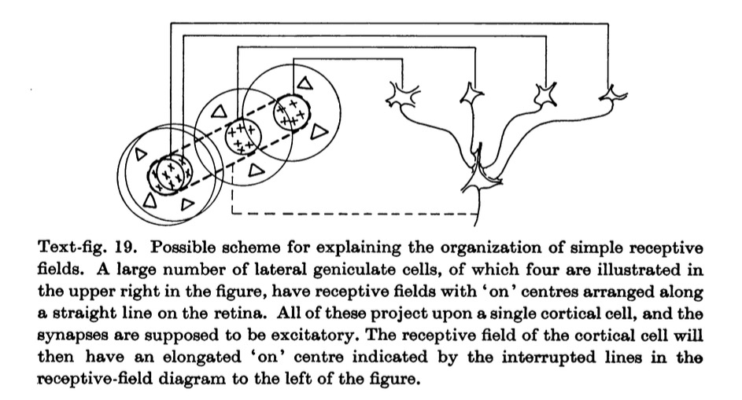

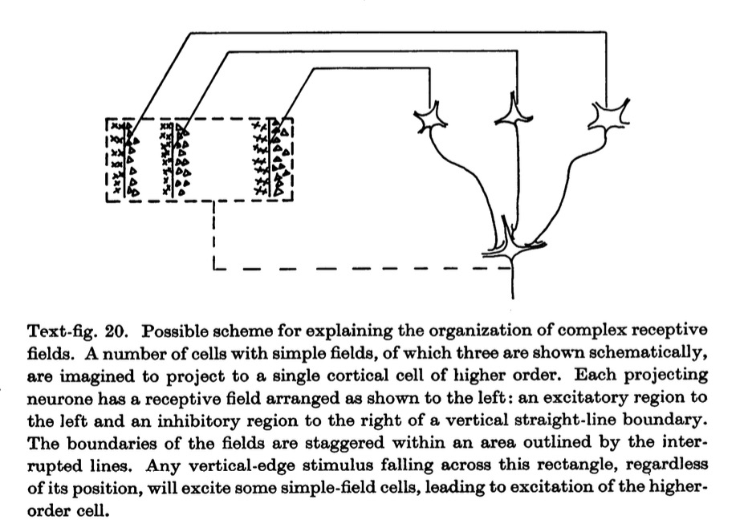

## Cortical hypercolumn

[figure not shown]

## Next time…

- Object processing
- Perrett, D. I., Rolls, E. T., & Caan, W. (1982). Visual neurones responsive to faces in the monkey temporal cortex. Experimental Brain Research, 47(3), 329–342. https://doi.org/10.1007/BF00239352